# Cryptography

Autumn 2025

## Terminology

- **Plaintext**: message which the cender wishes to keep secret.
- **Ciphertext**: scrambled plaintext, in a form that only the sender and intended recipient can read.
- **Cipher**: algorithm (mathematical function) which produces ciphertext, usually using a secret key.
- **Cryptography** is concerned with creating ciphers, **cryptanalysis** is concerned with breaking them.

## Substitution Cipher

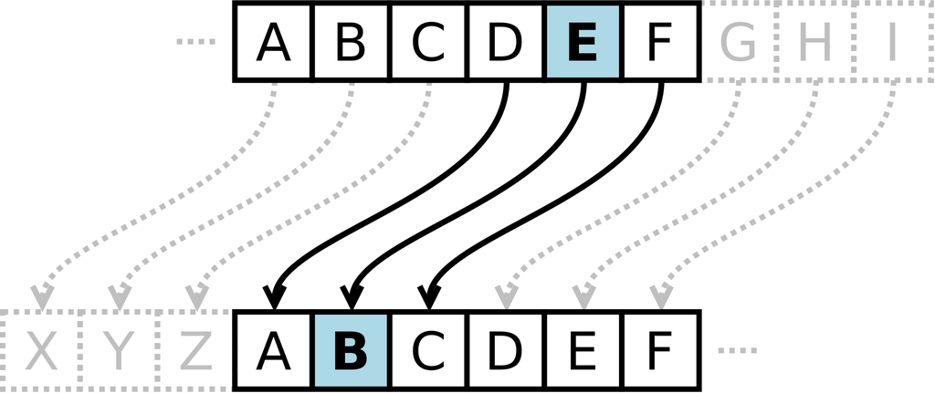

## Ancient Egypt

- Used obscure hyroglyphs to conceal secret messages.

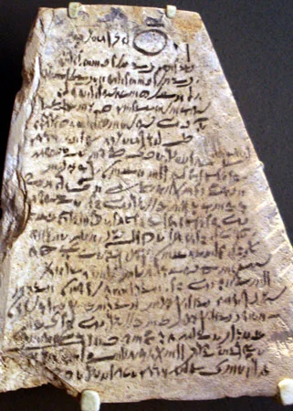

## Spartans

- *Scytale* was a rod with a strip wrapped around it.
- Sender wrote messages down the rod and unwrapped the strip.
- Only a recipient with a rod of the same diameter could decrypt the message.

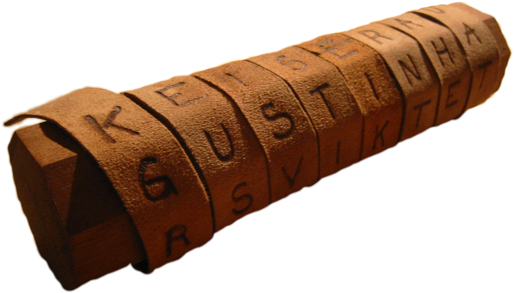

Scytale with leather strip wrapped around

## Karmasutra

- Karmasutra lists 64 arts which one needs to master to become a good lover.
- The 44th item is *Mlecchita Vikalpa*.
- Translation:

  “The art of understanding writing in cypher, and the writing of words in a peculiar way.”
- Presumably so that lovers could send each other secret messages.

[figure not shown]

6th- to 14th-century temples in Madhya Pradesh, Uttar Pradesh, Rajasthan, Gujarat, Karnataka, Chhattisgarh, Odisha, Tamil Nadu, Andhra Pradesh and Nepal.

## Mary Queen of Scots

- Babington Plot, 1586: plan to assasinate Elizabeth I.
- Another alphabetic substitution cipher, sometimes letters were replaced with numbers, symbols, or signs of the Zodiac.
- QE’s great spymaster, Sir Francis Walsingham,hired cryptanalysts, including Thomas Phelippes and John Sommers, who broke the cipher.

[figure not shown]

Page of ciphers used by Mary Queen of Scots

https://www.nationalarchives.gov.uk/education/resources/elizabeth-monarchy/ciphers-used-by-mary-queen-of-scots/

## Jefferson Disc

- Attributed to Thomas Jefferson, also called Bazeries cylinder or wheel cipher.
- Consisted of a set of numbered stackable discs with letters written around their edges in different orders.
- The sender would stack the discs in a particular order (the key) on a spindle.
- The message would be spelt out by rotating the discs and a different column would be read off as the ciphertext.
- The recipient would rotate the disks to show the ciphertext in order to read the plaintext off another column.

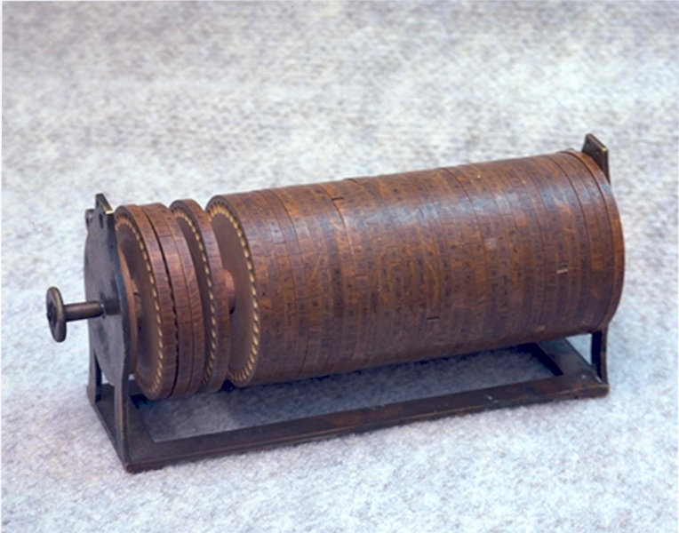

A disk cipher device of the Jefferson type from the 2nd quarter of the 19th century in the National Cryptologic Museum

## Cryptanalysis

- Art of breaking ciphers.
- Involves searching for patterns which gives the cryptanalyst clues.
- Al Kindi, from the Islamic Golden Age (Abbasid caliphate), first performed cryptanalysis.
- Used frequency analysis to break ciphers.

[figure not shown]

al-Kindi on Iraqi stamp from 1962

## Frequency Analysis

- Caesar’s Cipher shifts each letter by a given interval.
- In written language, letters appear more or less frequently.
- E.g., in English, `E` and `T` are the two most common letters.

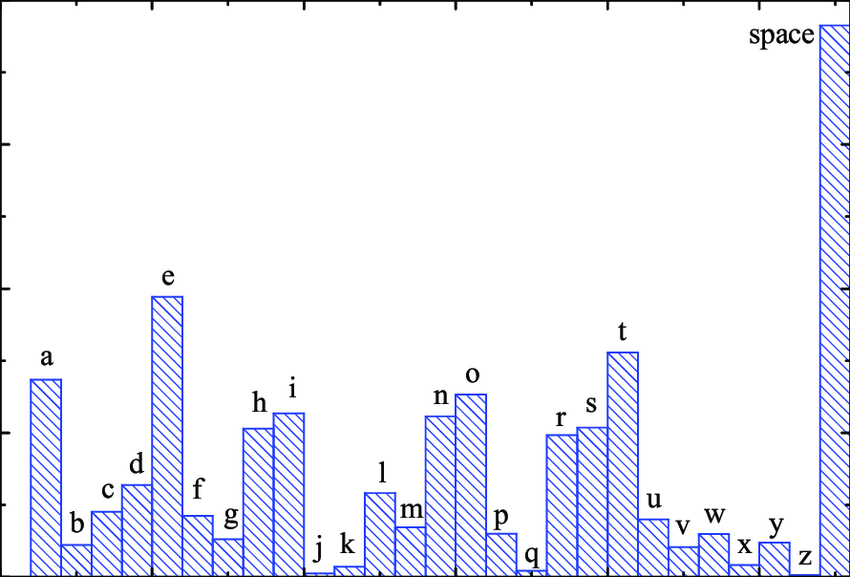

Histogram showing frequency analysis of letters in English written text

## FRequency Analysis

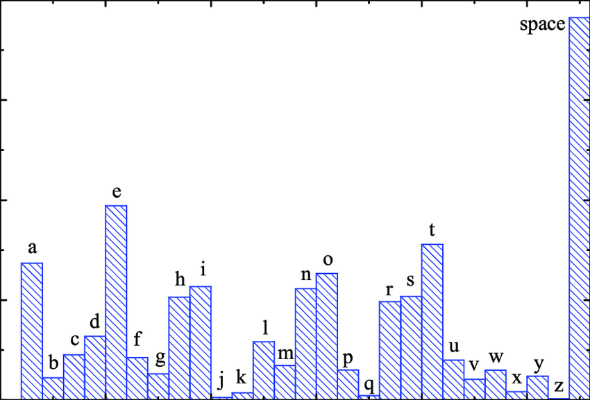

Histogram showing frequency analysis of letters in English written text

## Alberti Cipher

- Leon Battista Alberti created the first polyalphabetic substitution cipher and a machine (cipher disc) to automate it.
- Ordinary (monoalphabetic) substitutions replace each letter, e.g., `A` with `V`, ``E` with `S` and `T` with `X`.
- Polyalphabetic substitution performs different substitutions based on a letter’s position in the plaintext.
- E.g., `EE` encrypts to `SA`.
- No longer susceptible to frequency analysis alone.

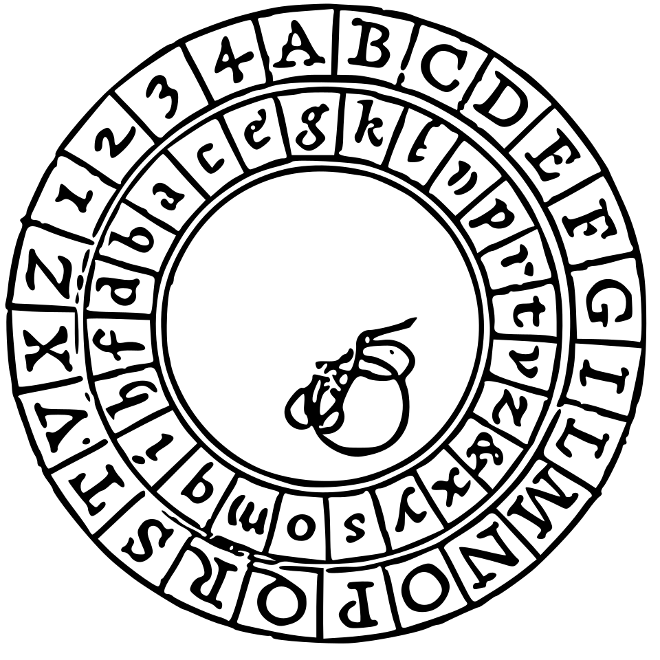

Alberti cipher disc

## Vigenere Cipher

- Named for Blaise de Vigenere, although first described by Giovan Battista Bellaso.
- Repeated sequence of Caesar Ciphers, shifts defined by the key, which is a word.
- Easy to implement, difficult to break.
- Called the "chiffrage indéchiffrable because it resisted cryptanalysis for three centuries.
- Eventually broken by Charles Babbage and Friedrich Kasiski in 1863.

## Example

```
m e n s a m e n s a m e n s a m e n s a m e n s a m e
E D L O N G F O R D I S T H E B E S T L E C T U R E R
Q H Y G N S J B J D U W G Z E N I F L L Q G G M R Q V
```

## Breaking the Vigenere Cipher

- Viginere cipher is not susceptible to straightforward frequency analysis, since the same letter may be encrypted to different letters at different points in the ciphertext.
- However, the key repeats – if the cryptanalyst knows the key length, \(n\), then they can perform \(n\) attacks on Caesar ciphers.
- The difficulty is finding the key length. The naive approach is brute force, but thert there are more sophisticated methods.

## Kasiski Examination

- Friedrich Kasiski published a method for determining key length in 1863.
- Involved looking for repeating patterns in the ciphertext.
  - Sometimes the same word is encrypted using the same letters of the key.
  - If there are repeated segments \(20\) characters apart, then the key length is likely a factor of \(20\) (\(1,2,4,5,10,20\)).
- Once the key length is determined, it remains to break \(n\) Caesar ciphers, e.g., by Frequency analysis.
- Same method used(but not published) by Charles Babbage in 1854.

## Zimmermann Telegram

- January 17, 1917, proposing a military contract between Germany and Mexico, allowing mexico to recover Texas, Arizona and New Mexico.
- German cables cut, Germany sent communications to Mexico via US, which were passed to Room 40 (British Intelligence).
- Decrypted using Wilhelm Wassmuss’ abandoned codebook, captured after the failed Niedermayer–Hentig Expedition to Afghanistan.
- British told the Americans that Mr H, a British spy, bribed an employee at the Mexican Telegram Office to give him a copy of the ciphertext, encrypted with an older cipher.
- Cover-story: British claimed that they obtained the plaintext from Mexico.

[figure not shown]

Zimmermann telegram

## Enigma

- Cipher and encryption machine developed by Arthur Scherbius near the end of WWI, used commercially then (Wehrmacht Enigma) adopted by Nazi Germany in WWII. -The Enigma machine had a keyboard for entering the message, a *reflector*, three *rotors*, a plug-board for implementing up to 13 additional substitutions and lights to indicate the enciphered letter.

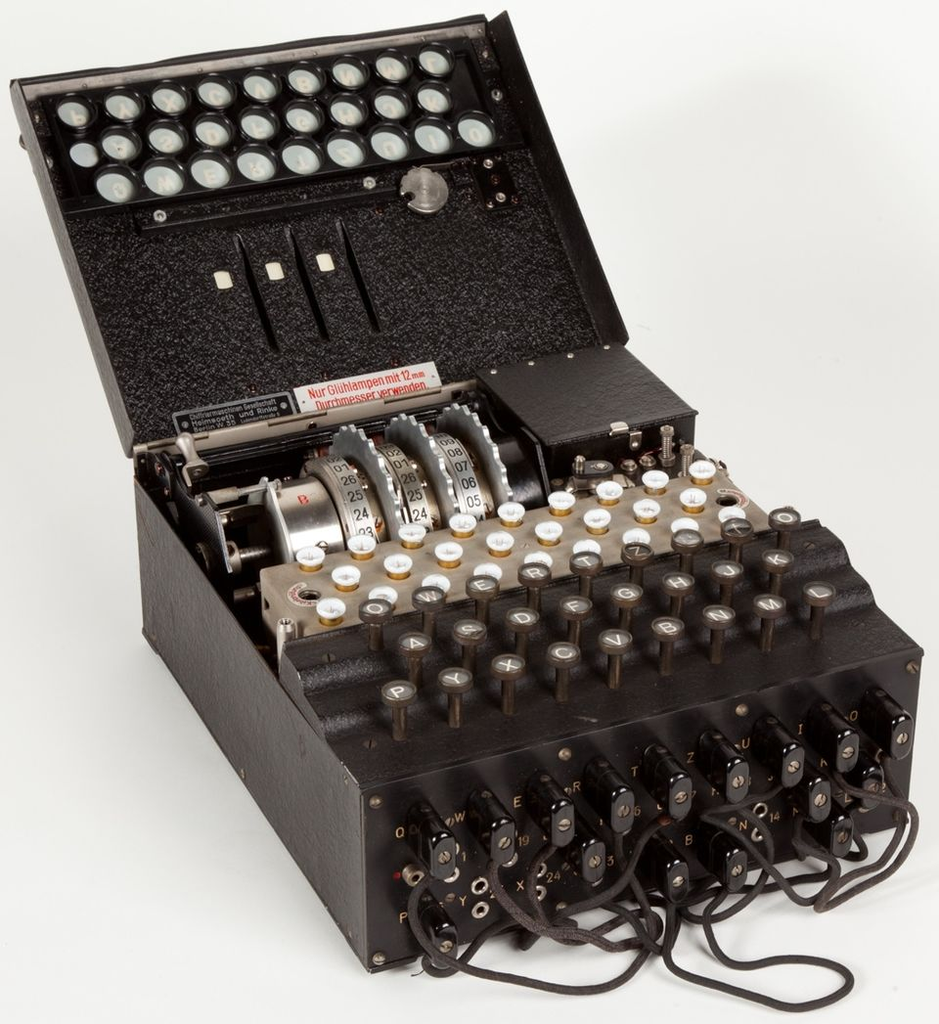

Military Model Enigma I, in use from 1930

## How it works

- Each rotor, and the reflector, performs a substitution.
- `INPUT -> Rot3 -> Rot2 -> Rot1 -> Reflector -> Rot1 -> Rot2 -> Rot3 -> OUTPUT`
- A key-press causes `Rot1` to increment by 1, changing the substitution.
- `Rot1` and `Rot2` have notches, which cause the subsequent rotor to increment by 1.
- The plug-board settings perform up to 13 additional substitutions, before and after a letter passes each rotor.
- Rotors can be placed in any order, and set at any start position.
- To decrypt, encrypt again with the same key.

## The Bombs

- Bletchley Park, home of Government Code and Cipher School (GCCS) now GCHQ, responsible for breaking secret communications in WW2.
- Enigma settings changed every 24 hours, there were 103 sextillion possible keys.
- Bom machines, designed by Alan Turing (based on a Polish idea), automated checking Enigma keys.
- First mass-produced special-purpose cryptanalytical machine.
- Able to decode encrypted messages quickly and pass on intelligence.
  - Battle of El Alamein (Egypt) in 1942 contributed to victory, proved to be a turning point in the war in North Africa.
  - Details of German defensive preparations for, and reactions to the D-Day invasion
  - Impact in many land, sea and air campaigns.

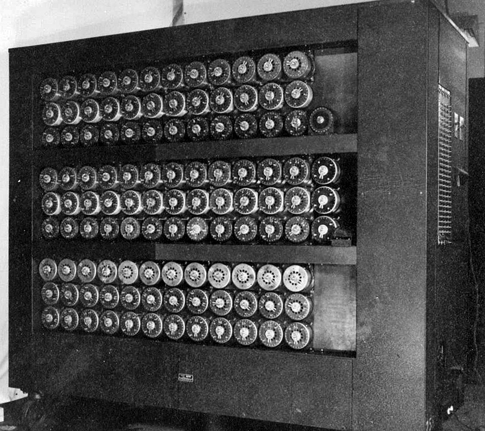

A wartime picture of a Bletchley Park Bombe

Bletchley park, manor house located in Buckinghamshire (now Milton Keynes), conveniently located near a railway line linking both Oxford and Cambridge. GCCS (Government code and cipher school, called Station X at the start of the war. Hired mathematicians,, experts at crosswords and chess, 3/4 of the staff were women. Hundreds of theBomb machines were operated by Wrens. It was said to be boring and oppressive work, with the women running the machines during long shifts in dark, stuffy rooms.

[video not shown]

## Tunny Teleprinter

- Communications network spanning Europe and North Africa, connecting Hitler and his troops.
- Used Lorenz cipher.
- Turing devised a method for systematically cracking Tunny ind 1942 (Turingery), lead to detailed knowledge of German strategy.
- Colossuss, Tommy Flowers’ first large-scale electronic computer ran advanced versions of Turing’s algorithm.

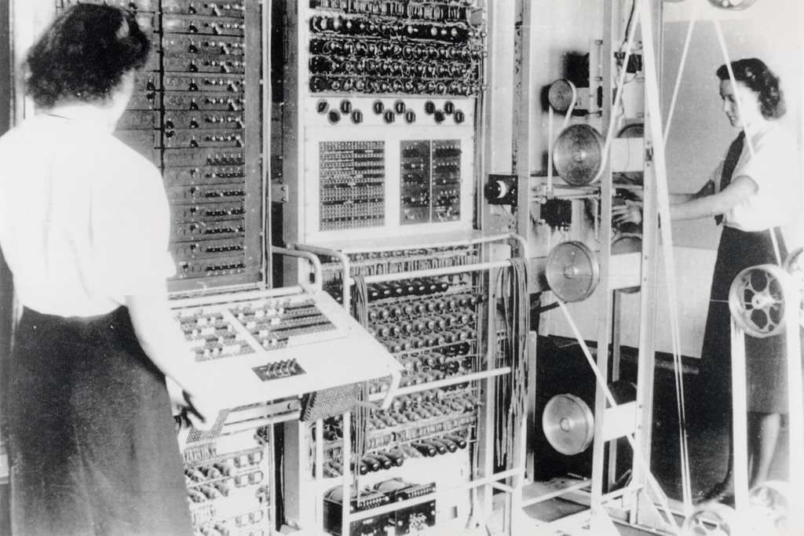

Colossus mark 2 being operated by Wrens

- Stibitz relay adder: https://www.youtube.com/watch?v=oGT1DTJFr8s
- ENIAC: https://www.youtube.com/watch?v=bGk9W65vXNA&t=11s
- Colossus, National Museum of Computing: https://www.youtube.com/shorts/QhmVSygPXcc
- “Why the first computers were made out of light bulbs” https://www.youtube.com/watch?v=FU_YFpfDqqA
- Talk on Colossus: https://www.youtube.com/watch?v=g2tMcMQqSbA

## Importance

- Turing and Bletchley Park’s other cryptologists helped counter the threat posed by Germany’s U-boats
- Turing stands alongside Churchill, Eisenhower, and a short glory-list of other wartime principals as a leading figure in the Allied victory over Hitler. There should be a statue of him in London among Britain’s other leading war heroes.
- Some historians estimate that Bletchley Park’s massive codebreaking operation, especially the breaking of U-boat Enigma, shortened the war in Europe by as many as two to four years.
- If Turing and his group had not weakened the U-boats’ hold on the North Atlantic, the 1944 Allied invasion of Europe - the D-Day landings - could have been delayed, perhaps by about a year or even longer, since the North Atlantic was the route that ammunition, fuel, food and troops had to travel in order to reach Britain from America.
- Harry Hinsley, a member of the small, tight-knit team that battled against Naval Enigma, and who later became the official historian of British intelligence, underlined the significance of the U-boat defeat.

  > Any delay in the timing of the invasion, even a delay of less than a year, would have put Hitler in a stronger position to withstand the Allied assault, Hinsley points out.

## Legacy

- Turing is known for many contributions to computer science, including the Turing Machine (mathematical model of a computer), work with Alonzo Church (Church-Turing thesis, stating that any algorithm can be coded), and the Turing Test (test for artificial general intelligence).
- Turing had a close friendship with Christopher Morcom while at school. After his early death, Turing was inspired to work especially hard on mathematics and science, interests shared with Morcom.
- Homosexuality was not legal in the UK until 1967 (not legalised in Scotland until 1980 and Northern Ireland until 1982).
- After reporting a burglary, and admitting that he had sexual relations with another man, Turing was convicted of gross indecency.
- Rather than going to prison, Turing agreed to undertake “chemical castration” treatment, injections of synthetic estrogen, causing unpleasant side-effects.
- Turing was found dead on 8 June 1954. It was suspected that he had taken his own life, a half-eaten apple contaminated with cianide was found next to his bed.
- Events at Bletchley Park were not declassified until after Turing’s death; he did not receive recognition for his achievements during his lifetime.

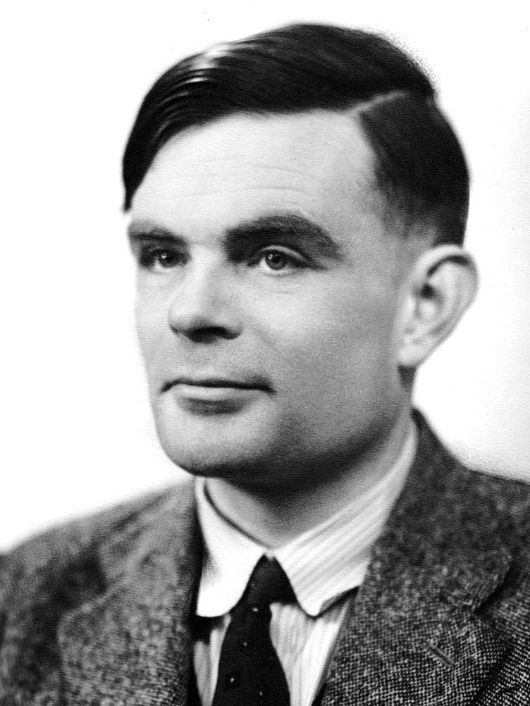

Turing in 1951

Alan Mathison Turing, 23 June 1912 - 7 June 1954 (aged 41).

## Feistel Ciphers

- Lucipher, precursor of DES, was designed by Horst Feistel, IBM, patented in 1971.
- Example of a block cipher, known as a Feistel Network.
- Data is split into “blocks”.
- A fixed number of encryption “rounds” are run on each block.
- After each round, one half of the data is XORed with the other half.
- This design guarantees that encryption can be undone, regardless of how complicated the round function is.

## Data Encryption Standard

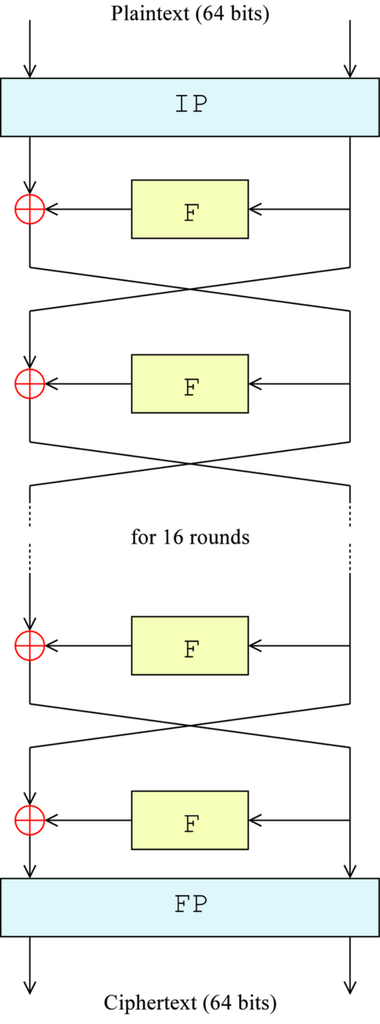

Shows the flow of DES algorithm

## Data Encryption Standard

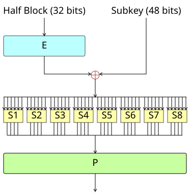

Flowchart of the F-function

*Key schedule*, converting 56-bit encryption key into sixteen 48-bit round keys is defined.

1. *Expansion*: Half of the bits are duplicated, expanding 32 to 48 bits.
2. *Key mixing*: XOR expanded input bits with a 48-bit subkey (different subkey for each round).
3. *Substitution*: 48-bits split into eight 6-bit pieces, each piece passed through “S-boxes”, functions which return 4 bits. S-boxes are non-linear lookup tables, which provides the security in DES (provides confusion).
4. *Permutation*: 32 bits are moved around, so that they are spread across different S-boxes in the next round (provides diffusion(.

## Data Encryption Standard

- U.S. encryption standard, based on Lucipher, first published in 19725, standardised in 1977.
- Used in banking, encryption of video streams by TV channels,.
- In 1991, Biham and Shamir “discover” differential cryptanalysis and apply it to a “DES-like” algorithm, theoretical (unrealistic) attack published in 1992.
- In 1997, a DES message was broken fro the first time in public by the DESCHAL project. In 1998, EFF breaks a DES key in 56 hours.
- In 1999, DES is reaffirmed, but use advised only for legacy systems, with triple DES preferred.
- Advanced Encryption standard released in 2001, with DES being withdrawn in 2005.
- Officially withdrawn in 2005.

## Advanced Encryption Standard

- Today’s widely accepted symmetric encryption standard.
- Block cipher developed by Joan Daemen and Vincent Rijmen.
- Rijndael cipher, substitution-permutation cipher which is not a Feistel network.
- Winner of a 5-year selection process, where 15 competing standards were proposed.

## AES

- Plaintext written out as a 2d array, round keys derived from encryption keys according to a Key Schedule.
- At each round:
  1. Non-linear substitution (lookup table).
  2. Row shift: last three rows of the grid are shifted cyclically.
  3. Linear mixing of columns.
  4. Add the round key.
- Final round does the same, but does not scramble columns before adding the round key.

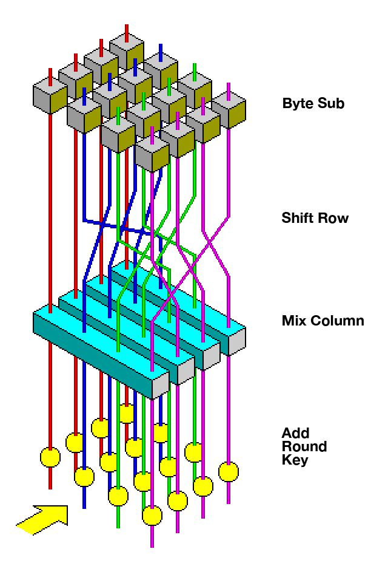

Diagram of AES round function